# 20220916_weekly_review_01

## Weekly Review (2022. 09. 13 ~ 16.)

- TUE : Matplotlib, Titanic dataset Analysis
- WED : Github Update, Matplotlib, Titanic dataset Analysis
- THU : Folium, Market dataset
- FRI : Folium, Pandas, Titanic dataset Analysis

### Matplotlib Review

- Matplotlib

  ```
  matplotlib(http://matplotlib.org/)은 python의 대표적인 과학 계산용 그래프 라이브러리로 선 그래프, 히스토그램, 산점도 등을 지원하며 출판에 쓸 수 있을만큼 고품질 그래프를 그려준다. 데이터와 분석 결과를 다양한 관점에서 시각화해보면 매우 중요한 통찰을 얻을 수 있다. (출처 : 파이썬 라이브러리를 활용한 머신러닝)
  ```

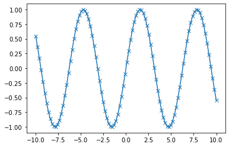

```python
%matplotlib inline
import matplotlib.pyplot as plt
import numpy as np

# -10에서 10까지 100개의 간격으로 나뉘어진 배열을 생성해보기
x = np.linspace(-10, 10, 100)

# sin 함수를 사용하여 y 배열을 생성해보기
y = np.sin(x)

# plot 함수는 한 배열의 값을 다른 배열에 대응해서 선 그래프를 그려준다.
plt.plot(x, y, marker='x')
```

#### 파이썬을 이용한 시각화 기본 (matplotlib)

1. 라이브러리 불러오기
2. 그래프 그려보기
3. 여러 개의 그래프 그리기
4. 범례 표시 - 기본

#### 01. 라이브러리 불러오기

```python
import matplotlib.pyplot as plt
import matplotlib

# 버전 확인
print(matplotlib.__version__)
```

```
3.3.2
```

#### 02. 그래프 그려보기

- 대부분의 matplotlib 라이브러리에서 그래프를 그리는 것이 pyplot 서브 모듈 아래에 있다. 보통 약자로 plt를 이용한다.
- 기본 plot()함수로 그래프를 표시한다.

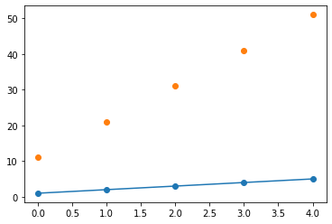

```python
import matplotlib.pyplot as plt

plt.plot([1,2,3,4,5], marker='o', linestyle='-')
plt.plot([11,21,31,41,51], "o")
plt.show()
```

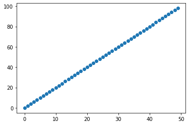

```python
x = range(0, 50)
y = range(0, 100, 2)
plt.plot(x, y, 'o')
plt.show()
```

##### matplotlib markers

- marker 인자 키워드를 사용하여 특별한 점을 강조한다.
- referance : https://www.w3schools.com/python/matplotlib_markers.asp

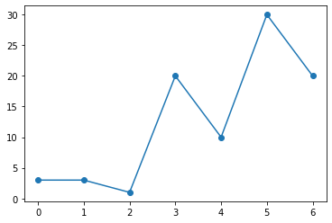

```python
import numpy as np
y = np.array([3,3,1,20,10,30,20])
plt.plot(y, marker='o')
plt.show()
```

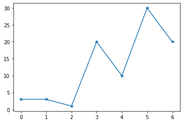

```python
plt.plot(y, marker='*')
plt.show()
```

##### y = x*x 그래프 그려보기

```
range(0, 30)
[0, 1, 4, 9, 16, 25, 36, 49, 64, 81, 100, 121, 144, 169, 196, 225, 256, 289, 324, 361, 400, 441, 484, 529, 576, 625, 676, 729, 784, 841]
```

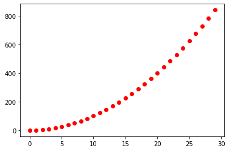

```python
x = range(0, 30)
y = [ v*v for v in x]
print(x)
print(y)

plt.plot(x, y, 'ro')
plt.show()
```

##### fmt의 파라미터를 다음과 같이 사용

- marker | line | color

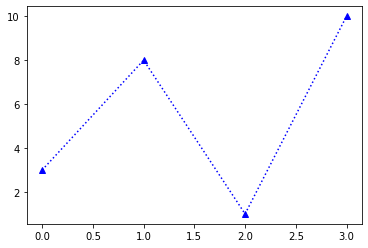

```python
y = np.array([3, 8, 1, 10])

plt.plot(y, '^:b')  # ^(삼각형), :(dotted line), b(blue)
plt.show()
```

##### 마커 사이즈(ms)

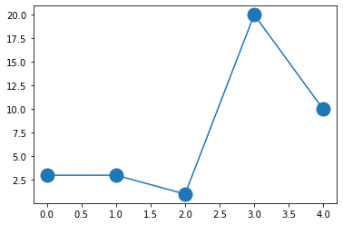

```python
y = np.array([3,3,1,20,10])

plt.plot(y, 'o-', ms=15)  # o(circle marker), -(solid line)
plt.show()
```

##### 마커 Edge 색 : Marker Edge Color (MEC)

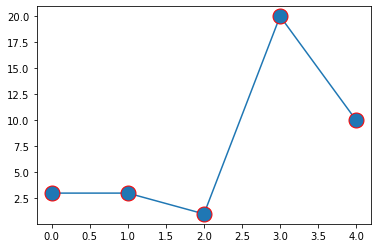

```python
y = np.array([3,3,1,20,10])

plt.plot(y, marker ='o', ms=15, mec='r')
plt.show()
```

##### markerfacecolor

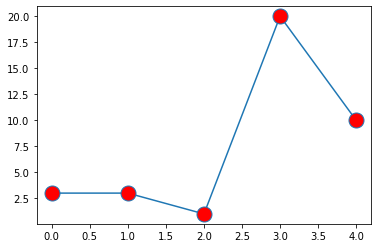

```python
plt.plot(y, marker='o', ms=15, mfc='r')
plt.show()
```

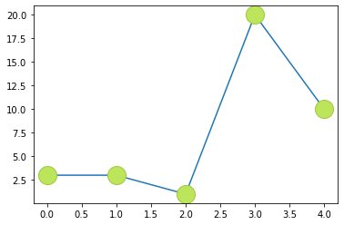

```python
plt.plot(y, marker='o', ms=20, mec='#9FC93C', mfc='#BCE55C')
```

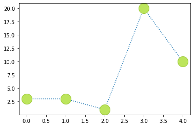

```python
plt.plot(y, marker='o', linestyle=':', ms=20, mec='#9FC93C', mfc='#BCE55C')
```

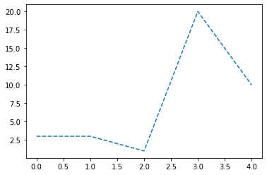

```python
plt.plot(y, linestyle = 'dashed')
```

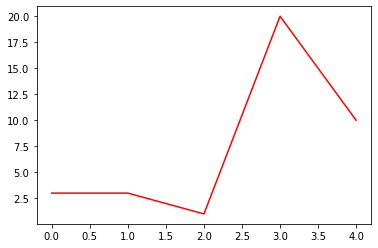

```python
plt.plot(y, color = 'r')
plt.show()
```

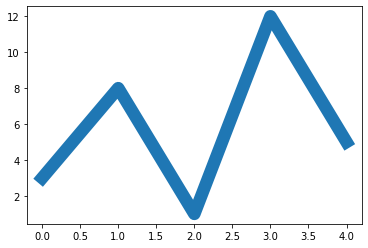

```python
### 선 굵기
y = np.array([3, 8, 1, 12, 5])
plt.plot(y, linewidth = '12.5')
```

#### 03. 여러 개의 그래프 그리기

- 한 화면에 여러개의 그래프를 그리기 위해서는
- (1) figure 함수를 통해 Figure 객체를 만든다.
- (2) add_subplot 메서드를 통해 그리려는 그래프 개수만큼 subplot을 만든다.

##### Figure 함수를 통해 Figure 객체를 만든다.

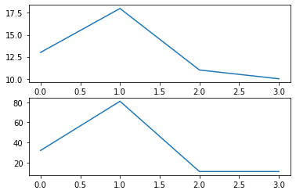

```python
fig = plt.figure()
ax1 = fig.add_subplot(2,1,1)
ax2 = fig.add_subplot(2,1,2)

x1 = np.array([0, 1, 2, 3])
y1 = np.array([13, 18, 11, 10])

x2 = np.array([0, 1, 2, 3])
y2 = np.array([32, 81, 11, 11])

ax1.plot(x1, y1)
ax2.plot(x2, y2)
plt.show()
```

##### add_subplot 메서드를 통해 그리려는 그래프 개수만큼 subplot을 만든다.

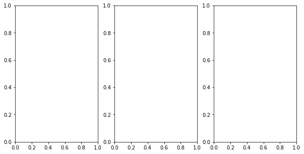

```python
fig = plt.figure(figsize=(10,5))

ax1 = fig.add_subplot(1,3,1)
ax2 = fig.add_subplot(1,3,2)
ax3 = fig.add_subplot(1,3,3)

plt.show()
```

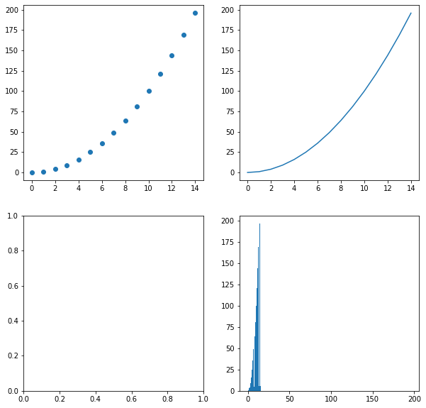

```python
# plot, bar 그래프 그리기
x = range(0, 15)
y = [ v * v for v in x ]

fig, axs = plt.subplots(2, 2, figsize=(10,10))
axs[0,0].plot(x, y, 'o')
axs[0,1].plot(x, y, '-')
axs[1,1].bar(x,y)
axs[1,1].hist(x,y)

plt.show()
```

##### sin, cos 그래프 그려보기

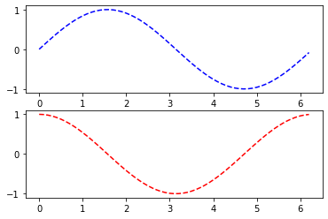

```python
import numpy as np
import matplotlib.pyplot as plt

x = np.arange(0.0, 2 * np.pi, 0.1)
sin_y = np.sin(x)
cos_y = np.cos(x)

plt.figure(figsize=(10,12))
fig, axs = plt.subplots(2)
axs[0].plot(x, sin_y, 'b--')
axs[1].plot(x, cos_y, 'r--')
plt.show()
```